# Continuous Random Data

Monika Peteva Petkova

mpetevap@uni-sofia.bg, monikapetevapetkova@gmail.com

2021

In statistics there are $3$ types of random variables:

- **Discrete /Дискретни/**
- **Continuous /Непрекъснати/**
- **Mixtures /Смеси/**

In this course we are going to review only the first two.

Let’s first explain some terms that we will need to use.

- For discrete random variable:
  - **Probability mass function (PMF) /Ред на разпределение/** - is a function that gives the probability that a discrete random variable is exactly equal to some value.
    $$P_X(x_i) := P(X = x_i)$$
    Example
    $$P_X(x_i) = P(X = x_i) = \begin{cases} 0.2, & x_i = 1 \\ 0.5, & x_i = 3 \\ 0.3, & x_i = 7 \\ 0, & otherwise \end{cases}$$

[figure not shown]

[output not shown]

$$F_X(x) := P(X \leq x) = \sum_{i: x_i \leq x}P(X = x_i)$$

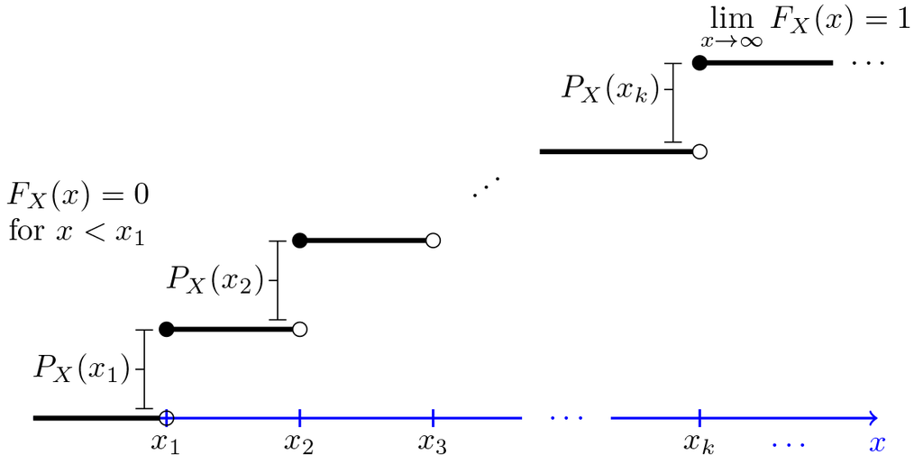

Example:

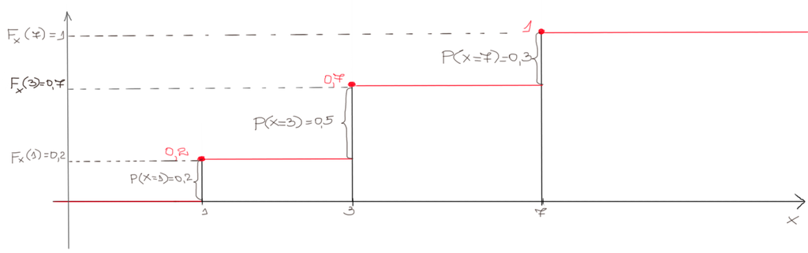

- For absolutely continuous random variable:
  - **Probability density function (PDF) /Плътност на разпределение/** - If the probability density function $f_X(x)$ exist, it is a non-negative function such that:
    $$F_X(x_0) = \int_{-\infty}^{x_0}f_X(x)dx$$
    and
    $$\int_{-\infty}^{\infty}f_X(x)dx = 1$$

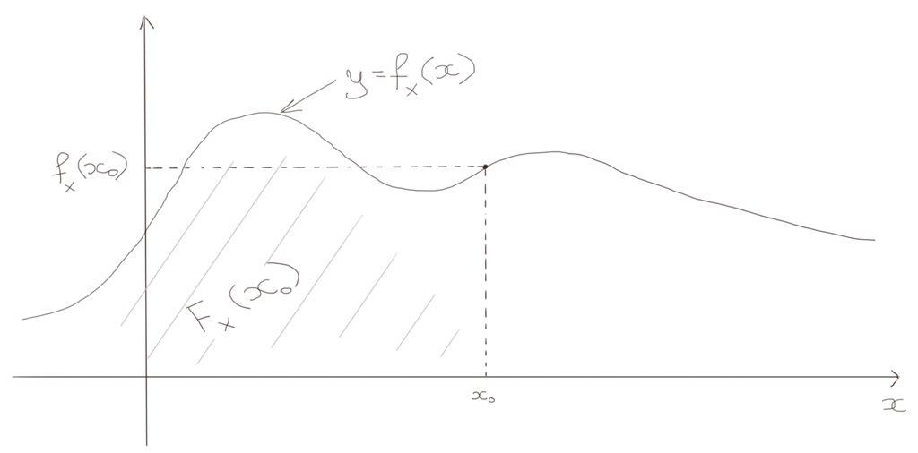

  - **Cumulative distribution function (CDF) /Кумулативна функция на разпределение/** - is the probability that a random variable $X$ will take a value less than or equal to $x$.
    $$F_X(x) := P(X \leq x)$$
- **Moments** - quantitative measures related to the shape of the function
  - **First moment /Expectation, Mean/**
    $$\mu = E[X] = \int_{-\infty}^{+\infty}{xdF_X(x)}$$
  - **Second central moment /Variance/**
    $$\sigma^2 = Var[X] = D[X] = E[(X - E[X])^2] =$$
    $$= E[X^2 - 2XE[X] + (E[X])^2] =$$
    $$= E[X^2] - 2E[X]E[X] + (E[X])^2 =$$
    $$= E[X^2] - (E[X])^2$$
  - **Third standardized moment /Skewness/**
    $$\operatorname{E}\left[\left(\frac{X - \mu}{\sigma}\right)^3 \right] = \frac{E(X - \mu)^3}{\sigma^3}$$

[figure not shown]

    We also say that the data on the first graphic is **left-skewed** and the data on the second graphic is **right-skewed**.

  - **Fourth standardized moment**
    $$\operatorname{E}\left[\left(\frac{X - \mu}{\sigma}\right)^4 \right] = \frac{E(X - \mu)^4}{\sigma^4}$$
    $$\text{Kurtosis} = \text{Fourth standardized moment} - 3$$

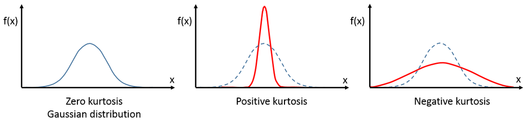

  They are also named: **Mesokurtic /Normal/**, **Leptokurtic**, **Platykurtic**